# Cracking Open Machine Learning for Education Data Strategists

Tom Hay

May 19, 2017

# The Purpose of This Presentation

To demystify “Machine Learning” for the Data Strategist.

- I will explain three types of machine learning problems:
  - Classification
  - Clustering
  - Regression
- You will learn how identify what would constitute a machine learning problem in Education.
- We will talk through a vignette of how to build a machine learning model.
- I will give you some tips and available resources based on lessons I learned through the process

# Quick Introduction

- My name is Tom Hay
- I am the Director of Data Strategy for Uplift Education
- Uplift Education is a public pre-K to 12 college preparatory charter school network of 16,000 students in Dallas-Ft. Worth
- A downloadable copy of this presentation is available at https://github.com/UpliftDAT along with the code used to build the models
- Infrequent tweeting via @UpliftDAT

# What is everyone’s comfort level with Machine Learning?

0. Hold up a fist if you are everything on the last slide confusing to you
1. Hold up a single finger if you have heard the term “Machine Learning”
2. Hold up two fingers if you can name one type of machine learning model
3. Hold up three fingers if you have created a machine learning model
4. Hold up four fingers if this is something you are using at your agency right now
5. High Five if you are running machine learning models on in-flight data at your agency

# What is Machine Learning?

- Using and building algorithms that “learn” from data using statistical techniques
- More information (observations, experiences, instances) should result in higher performance, i.e. the model improves when more information is received
- Statistical learning techniques allow for identication of patterns within data
- For the Education Data Strategist, machine learning will focus on making predictions based on the identified patterns

# So…what is a Machine Learning Problem?

- Spam Filtering
- Netflix’s Movie Recommendations
- Google Autocomplete
- Facebook Photo Autotagging

# Okay….then what is an Education-related Machine Learning Problem?

- Will a student reenroll in college?
- What colleges will a student be accepted to?
- Will a teacher stay with the district?
- Who might have to go to summer school?

# Types of Machine Learning Problems

- Classification: Predicting the category (or class) of a new observation
  - Qualitative or quantitative output, predefined categories (classes)
- Clusterting: Group similar objects or observations in clusters, but the clusters are dissimilar from each other
  - Don’t need knowledge about the labels, no right or wrong as clustering reveals more information about your data, but there **may be** an expectataion of a certain result based on prior knowledge
- Regression: Predicting a continous, quantitative value of a new observation
  - Fitting a function, quantitative output, continuous, trying to find good values for your coefficients, output is based on prior modeled observations

# Supervised Learning vs Unsupervised Learning

- Supervised: Observations are labeled
  - Can compare predicted labels to lables not predicted
- Unsupervised: Observations are not labeled
  - Clustering is Unsupervised Learning, as labeled observations are not required
  - No labels to compare to
- Semi-Supervised: Some observations are labeled, most are not.

# Let’s Build a Machine Learning Model!

# Vignette on Binary-Class Classification Problem

- 87% of Uplift Education graduates enroll in college
- After graduating, about 10% of our total graduates per graduation year end up leaving college without completing it
- We wanted to create a model to predict which students were unlikely to enroll for their sophomore year
- This would allow our Alumni Counselors to spend more time working with these students, so as to insulate them against factors contributing to them dropping out

# Steps

1. Identify Data Set
2. Determine what type of model we may want to use
3. Feature Selection
4. Split Data Set into training data and test data
5. Train model on training data set
6. Evaluate model on test data set
7. Repeat using different model/feature set
8. Compare models and pick the best one

# Before We Start, Some Notes on Software Choices

- I used R
  - Open-Source
  - Lots of great machine learning Packages
  - I’m most familiar with it
  - R Scripts can run on SQL Server 2016
- Python is another great open-source option, scripts will run on SQL Server 2017

# 1. The Data

- Academic Data of Uplift Graduates, collected via assessments and our Student Information System, uploaded to our data warehouse
- Table of Reenrollment Records, collected via the [National Student Clearinghouse](http://www.studentclearinghouse.org/), cleaned by Alumni Counselors, and uploaded to our data warehouse
- [Database of College Data](https://collegescorecard.ed.gov/data/) from the [College Scorecard](https://collegescorecard.ed.gov/), via the Department of Education
- Barron’s Selectivity Data, collected for schools that Uplift graduates enroll in, via Barron’s Profiles of American Colleges
- **No data on classes taken during freshman year, or anything that happened during freshman year other than their initial enrollment**

# 2. Type of Model to Use

- Based on what we learned, I would say this is a **Classification Problem**
- Therefore, I’m going to use a classification model called Classification and Regression Trees (CART)
- Useful because it can handle both numeric and categorical data implicitly - giving flexibility in our features aka minimal data preparation
- Also easy to visualize, making it a bit simpler to understand
- Downside is that prediction performance is often poor due to high variance

# 3. Feature Selection

- Our Features
  - Barron’s Selectivity (from Barron’s Profiles of American Colleges)
  - In or Out of State
  - Student Maximum Composite ACT Score
  - Simple GPA
  - Average Cost of Attendance of the School per year
  - Two or Four Year College
  - High School the Student Attended

# 4. Splitting the data

- Best practice is to split our data into a **training set** and a **test set**, so we can build our model on one set of data and evaluate it’s effectiveness on another set of data
- In this case, we split the data 70/30 for training and test, giving us 260 observations in our training set and 111 observations in our test set

# 5. Train a Model

# 5. Our Model, Visualized as a Decision Tree

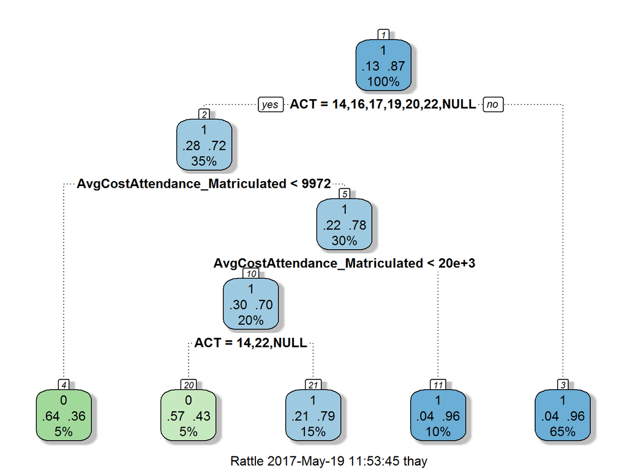

# 5. Reading the Decision Tree

- If the answer to the criteria is yes, follow to the left
- If the answer to the criteria is no, follow to the right
- At each decision point, called a “node”, we can see the distribution of our training set that splits or “branches” into each yes or no categorization.
- We follow down until we reach the terminating node, called the “leaf”
- If we want to remove certain criteria, we can “prune” the tree, removing leafs that don’t provide enough information

# Wait, how did this Decision Tree get built?

- In this model, the math behind it is called the [Gini impurity](https://en.wikipedia.org/wiki/Decision_tree_learning)
- It determines the highest value splits based on this algorithm
- The math behind this is not simple, but less complex than other machine learning models - but more on that later…

# 6. How to Evaluate if a Machine Learning Model is Good/Useful

- Classification
  - **Confusion Matrix, Accuracy and Error (Number of times the system is right or wrong), Area Under the Curve (AUC)**
- Clustering
  - Similarity within cluster (want to be high) and similarity between clusters (want to be low)
  - Within cluster sum of squares, diameter, between cluster sum of squares, intercluster distance
- Regression
  - Root Mean Square Error, R-squared

# 6. The Confusion Matrix and Accuracy

```
##    pred2
##      0  1
##   0  4 14
##   1  8 85
```

```
## [1] 0.8018018
```

> Accuracy = (True Positives + True Negatives)/All Observations

# 6. The Reciever Operator Characteristic (ROC) Curve

- We can also output a probability that an unseen observation is in a particular class via the decision tree or k-nearest neighbor methods.
- This allows us to define the probability threshold, also known as the Decision Function
- Confusion Matrix is used to construct the ROC curve, by using the true positive Rate (or Recall) and the false positive rate

# 6. The ROC Curve Continued

- Need a classifier that outputs class probabilities - called the Decision Function
- True Positive Rate goes on the y-axis
- False Positve Rate goes on the x-axis
- The Closer the curve is to the upper left corner, the better the classifier is
- Therefore you want to maximize the Area Under the Curve (AUC). A number closer to 1 is better, and allows you to compare different models

# 6. Our ROC Curve

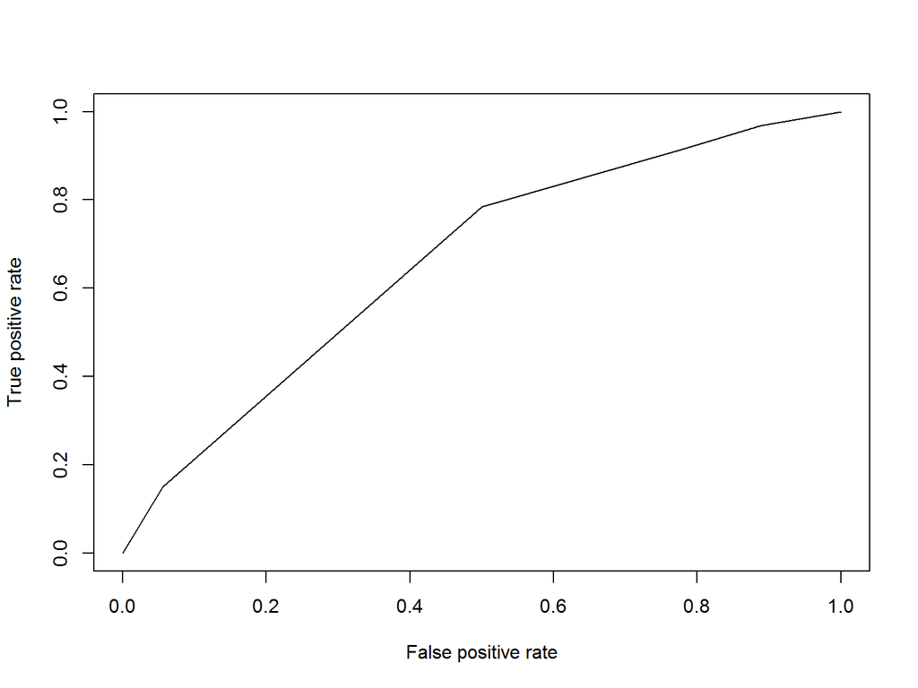

```
## [1] 0.6618877
```

# 7. Repeated Using a Larger Data Set

- I’ve added the Class of 2014 and 2013 to the data set, giving us 802 observations in our training set and 343 observations in our test set

# 7. New Decision Tree

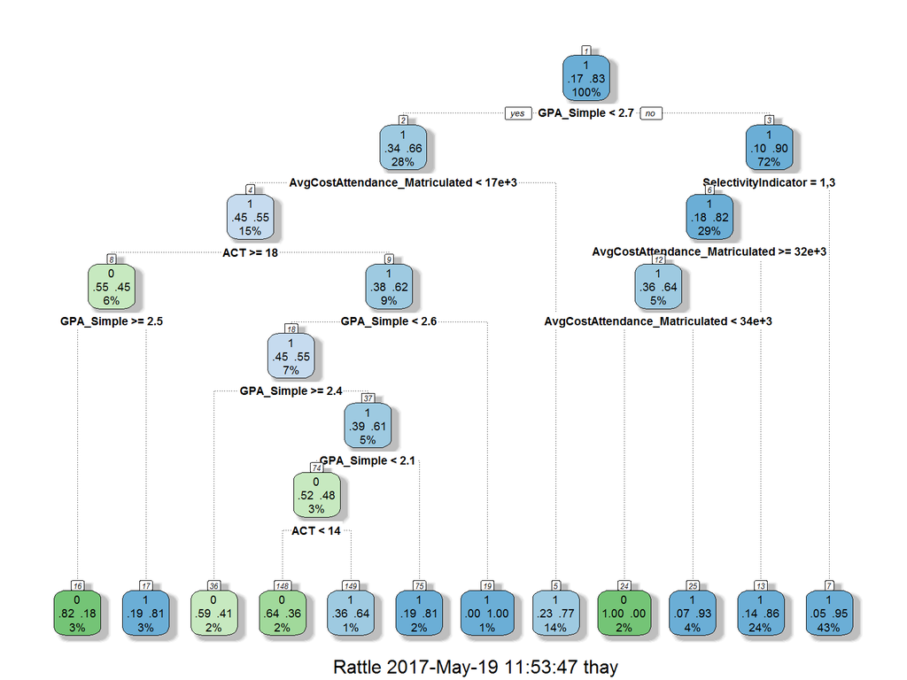

# 7. New Confusion Matrix and Accuracy

```
##    pred
##       0   1
##   0  14  42
##   1   7 280
```

```
## [1] 0.8571429
```

# 8. Choosing the best Model

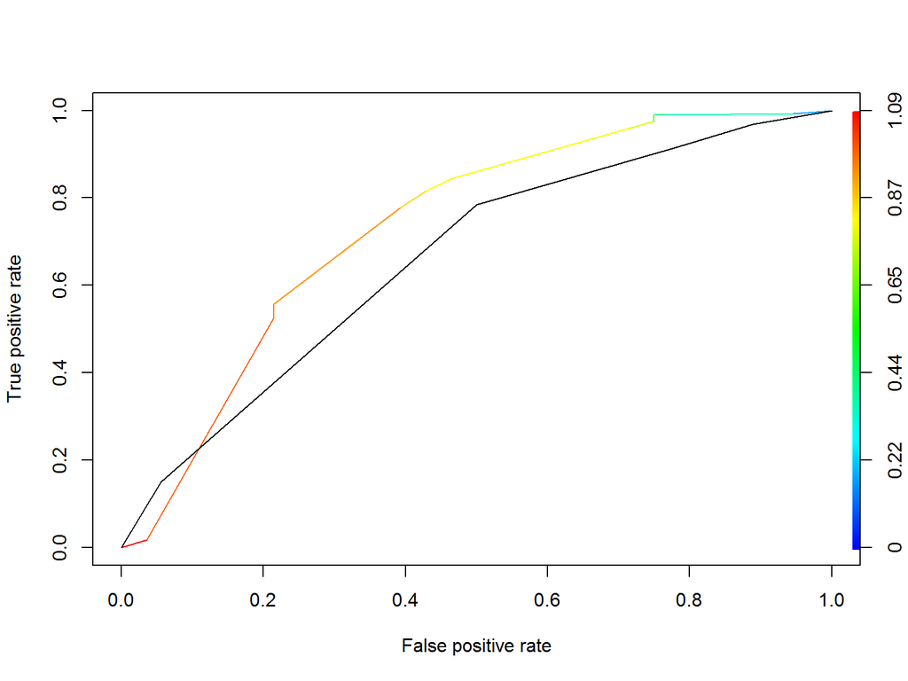

New AUC

```
## [1] 0.7338228
```

# Now What?

- We just walked through the process of building a classification and regression tree (CART), a type of classification model
- Imagine doing this process iteratively over and over again, adding more data and resampling that data uing **k-fold cross validation** - randomly partitioning the data into k-sized subsamples and retraining and testing the model.
- Ideally, the model performance will continue improve with more data, and allow the model to better generalize to unobserved data
- We might also want to try other types of models to see if they improve our ability to correctly classify the data

# Words of Caution

- Beware overfitting the data
- Recognize cases where a feature might have a new type of observation - ex. a graduating class from a new high school
- Poor sampling of data will lead to a biased model

# More Words of Caution

- Big B Biases are present in our data - particularly in Education Data!
- Models that predict inequitable outcomes - something seen in the model we just built - are typically due to data that reflect these inequitable outcomes
- Be careful in choosing your features - there is not a hard and fast mathematical rule you can apply to detect features that are rooted in inequity
- If a model was used to give out loans from a bank, and race or ethnicity were a feature that decided what interest rate to offer to clients, then the model would be **discriminatory**
- Can you think of situations where you might want to proceed with caution when dumping data into a model and just using the output?

# More Words of Caution

- Machine learning models, depending on their complexity, are difficult to explain
- For this overview, the explanations are simplified to make them accessible
- There is a black box nature to machine learning, in that some of models that produce the greatest accuracy - like Neural Networks and Stacked Models, are incredibly difficult for data scientists to explain
- So how are you going to explain a model you struggle to understand to the end user?

# So why should we even use Machine Learning?

- This is another tool in your tool kit to reveal patterns in your data.
- If the patterns you reveal allow your district to make better decisions, or make predictions more accurate than human intuition, these are very useful.
- Used in a production setting, then can also be combined with human intuition to guide staff through a decision-making process.
- It is worth knowing about machine learning, as they algorithms underpin many tools we are using in education - like ed tech and adaptive tests - and our every day lives.

# Ready to take the jump into building your own models?

Tutorials for R - Jason Brownlee [Your First Machine Learning Project in R Step-By-Step (tutorial and temple for future projects)](http://machinelearningmastery.com/machine-learning-in-r-step-by-step/)

- [RPart Vignette](https://cran.r-project.org/web/packages/rpart/vignettes/longintro.pdf)

# References

- Data Camp [Introduction to Machine Learning](https://www.datacamp.com/courses/introduction-to-machine-learning-with-r)
- Erin LeDell [Machine Learning Algortihmic Deep Dive](http://user2016.org/tutorials/10.html)
- Tony Chu, Stephanie Yee [A Visual Introduction to Machine Learning](http://www.r2d3.us/visual-intro-to-machine-learning-part-1/)
- Jason Brownlee [Your First Machine Learning Project in R Step-By-Step (tutorial and temple for future projects)](http://machinelearningmastery.com/machine-learning-in-r-step-by-step/). machinelearninmastery.com.
- [Decision Tree Learning](https://en.wikipedia.org/wiki/Decision_tree_learning)

# Thank you’s

- A big thanks to Kim Lammers, Data Analyst at Uplift Education, for assistance with creating these models and this presentation. It was a collaborative effort.
- Check out Kim’s great work at her [Tableau Public Page](https://public.tableau.com/profile/kim.lammers#!/vizhome/UpliftEducationCollegeMatchingDashboard/BarronsSelectivitySelector).